# Modeling_Case_Study

```python
import pandas as pd
import numpy as np
import matplotlib.pyplot as plt
import os
import seaborn as sns
import sys
import glob as gb
import json
import datetime as dt

pd.set_option('display.max_rows', 250)


# makes plots nice
def make_pretty(ax, title='', x_label='', y_label='', img=False):
    ax.set_title(title, fontsize=20)
    ax.set_xlabel(x_label, fontsize=16)
    ax.set_ylabel(y_label, fontsize=16)
    ax.legend(loc='best', fontsize=16)
    if img:
        ax.axis('off')
    return ax

def make_hist(ax, col, df):
    print(f'Min of {col}: {df[col].min()}')
    print(f'Max of {col}: {df[col].max()}')
    ax = df[col].plot(kind='hist', ax=ax)
    make_pretty(ax, f'{col} Histogram', col, 'Frequency')

def make_bar(ax, col, df):
    vc = df[col].value_counts()

    ax = vc.plot(kind='bar', ax=ax)
    make_pretty(ax, col, f'{col} labels', f'{col} value counts')
    return ax
```

A rideshare company is interested in predicting rider retention. You are provided a sample dataset of a cohort of users who signed up for an account in January 2014. The data was collected on July 1, 2014, and it consits of the following columns:

### Data description

- **city**: city this user signed up in
- **phone**: primary device for this user
- **signup_date**: date of account registration; in the form ‘YYYYMMDD’
- **last_trip_date**: the last time this user completed a trip; in the form ‘YYYYMMDD’
- **avg_dist**: the average distance in miles per trip taken in the first 30 days after signup
- **avg_rating_by_driver**: the rider’s average rating over all of their trips
- **avg_rating_of_driver**: the rider’s average rating of their drivers over all of their trips
- **surge_pct**: the percent of trips taken with surge multiplier > 1
- **avg_surge**: The average surge multiplier over all of this user’s trips
- **trips_in_first_30_days**: the number of trips this user took in the first 30 days after signing up
- **premium_ride_service**: TRUE if the user requested a premium ride service in their first 30 days; FALSE otherwise
- **weekday_pct**: the percent of the user’s trips occurring during a weekday

We consider a user retained if they were “active” (i.e. took a trip) in the last 30 days preceding July 1, 2014. We would like you to use this data set to help understand what factors are the best predictors for retention.

1. Perform any cleaning, exploratory analysis, and/or visualizations to use the provided data for this analysis. What fraction of the observed users were retained/active?
2. Build a predictive model that can predict whether or not a user will be active in their 6th month on the system. Explain your experimental setup and what evaluation metric you choosed.
3. Briefly discuss the insights gained from the model.

### Cleaning

```python
data = os.path.join("users_data.csv")


df = pd.read_csv(data)
```

```python
df.head()
```

|  | city | trips_in_first_30_days | signup_date | avg_rating_of_driver | avg_surge | last_trip_date | phone | surge_pct | premium_ride_service | weekday_pct | avg_dist | avg_rating_by_driver |
| --- | --- | --- | --- | --- | --- | --- | --- | --- | --- | --- | --- | --- |
| 0 | C | 4 | 2014-01-25 | 4.7 | 1.10 | 2014-06-17 | iPhone | 15.4 | True | 46.2 | 3.67 | 5.0 |
| 1 | B | 3 | 2014-01-06 | 4.3 | 1.00 | 2014-01-07 | iPhone | 0.0 | False | 100.0 | 0.77 | 5.0 |
| 2 | C | 9 | 2014-01-10 | 4.6 | 1.14 | 2014-06-29 | iPhone | 20.0 | True | 80.0 | 2.36 | 4.9 |
| 3 | A | 14 | 2014-01-27 | 4.4 | 1.19 | 2014-03-15 | Android | 11.8 | False | 82.4 | 3.13 | 4.9 |
| 4 | A | 2 | 2014-01-09 | 3.5 | 1.00 | 2014-06-06 | iPhone | 0.0 | True | 100.0 | 10.56 | 5.0 |

```python
df['premium_ride_service'].value_counts()
```

```
False    21185
True     13481
Name: premium_ride_service, dtype: int64
```

```python
df.info()
```

```
<class 'pandas.core.frame.DataFrame'>
RangeIndex: 34666 entries, 0 to 34665
Data columns (total 12 columns):
 #   Column                  Non-Null Count  Dtype
---  ------                  --------------  -----
 0   city                    34666 non-null  object
 1   trips_in_first_30_days  34666 non-null  int64
 2   signup_date             34666 non-null  object
 3   avg_rating_of_driver    30266 non-null  float64
 4   avg_surge               34666 non-null  float64
 5   last_trip_date          34666 non-null  object
 6   phone                   34348 non-null  object
 7   surge_pct               34666 non-null  float64
 8   premium_ride_service    34666 non-null  bool
 9   weekday_pct             34666 non-null  float64
 10  avg_dist                34666 non-null  float64
 11  avg_rating_by_driver    34558 non-null  float64
dtypes: bool(1), float64(6), int64(1), object(4)
memory usage: 2.9+ MB
```

```python
df['phone'].value_counts()
```

```
iPhone     23922
Android    10426
Name: phone, dtype: int64
```

### Making variables correct type

```python
df['city'] = df['city'].astype('category')
df['signup_date'] = pd.to_datetime(df['signup_date'])
df['last_trip_date'] = pd.to_datetime(df['last_trip_date'])

df['phone'] = df['phone'].astype('category')
df['premium_ride_service'] = df['premium_ride_service'].astype('bool')
df.info()
```

```
<class 'pandas.core.frame.DataFrame'>
RangeIndex: 34666 entries, 0 to 34665
Data columns (total 12 columns):
 #   Column                  Non-Null Count  Dtype
---  ------                  --------------  -----
 0   city                    34666 non-null  category
 1   trips_in_first_30_days  34666 non-null  int64
 2   signup_date             34666 non-null  datetime64[ns]
 3   avg_rating_of_driver    30266 non-null  float64
 4   avg_surge               34666 non-null  float64
 5   last_trip_date          34666 non-null  datetime64[ns]
 6   phone                   34348 non-null  category
 7   surge_pct               34666 non-null  float64
 8   premium_ride_service    34666 non-null  bool
 9   weekday_pct             34666 non-null  float64
 10  avg_dist                34666 non-null  float64
 11  avg_rating_by_driver    34558 non-null  float64
dtypes: bool(1), category(2), datetime64[ns](2), float64(6), int64(1)
memory usage: 2.5 MB
```

```python
df.head()
```

|  | city | trips_in_first_30_days | signup_date | avg_rating_of_driver | avg_surge | last_trip_date | phone | surge_pct | premium_ride_service | weekday_pct | avg_dist | avg_rating_by_driver |
| --- | --- | --- | --- | --- | --- | --- | --- | --- | --- | --- | --- | --- |
| 0 | C | 4 | 2014-01-25 | 4.7 | 1.10 | 2014-06-17 | iPhone | 15.4 | True | 46.2 | 3.67 | 5.0 |
| 1 | B | 3 | 2014-01-06 | 4.3 | 1.00 | 2014-01-07 | iPhone | 0.0 | False | 100.0 | 0.77 | 5.0 |
| 2 | C | 9 | 2014-01-10 | 4.6 | 1.14 | 2014-06-29 | iPhone | 20.0 | True | 80.0 | 2.36 | 4.9 |
| 3 | A | 14 | 2014-01-27 | 4.4 | 1.19 | 2014-03-15 | Android | 11.8 | False | 82.4 | 3.13 | 4.9 |
| 4 | A | 2 | 2014-01-09 | 3.5 | 1.00 | 2014-06-06 | iPhone | 0.0 | True | 100.0 | 10.56 | 5.0 |

```python
df['retained'] = df['last_trip_date'].apply(lambda x : 1 if x > dt.datetime(2014, 6, 1) else 0)
```

```python
df['retained'].value_counts()
```

```
0    21688
1    12978
Name: retained, dtype: int64
```

```python
np.mean(df['retained']==1)
```

```
0.37437258408815555
```

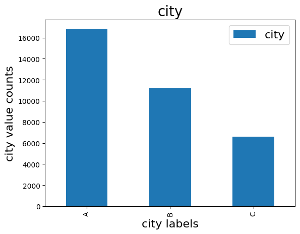

```python
fig, ax = plt.subplots()

make_bar(ax, 'city', df)
```

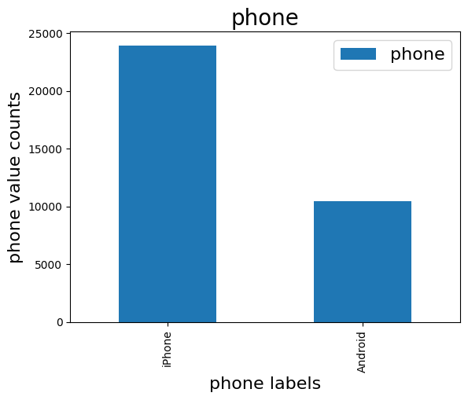

```python
fig, ax = plt.subplots()

make_bar(ax, 'phone', df)
```

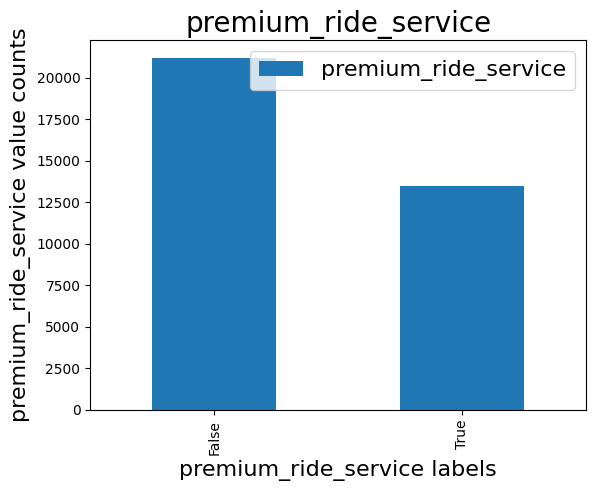

```python
fig, ax = plt.subplots()

make_bar(ax, 'premium_ride_service', df)
```

```
Min of trips_in_first_30_days: 0
Max of trips_in_first_30_days: 125
```

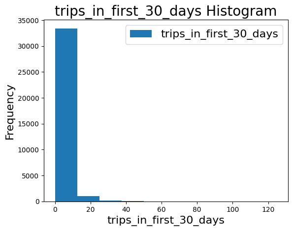

```python
fig, ax = plt.subplots()

make_hist(ax, 'trips_in_first_30_days', df)
```

```
Min of avg_rating_of_driver: 1.0
Max of avg_rating_of_driver: 5.0
```

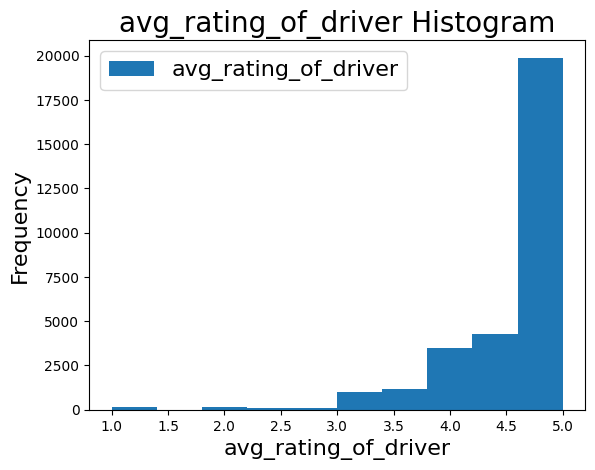

```python
fig, ax = plt.subplots()

make_hist(ax, 'avg_rating_of_driver', df)
```

```
Min of avg_surge: 1.0
Max of avg_surge: 8.0
```

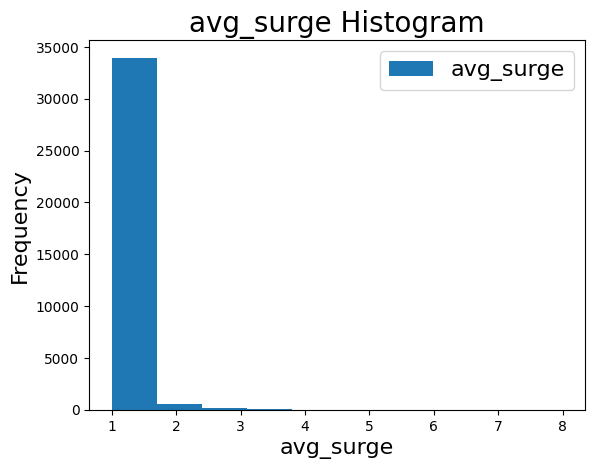

```python
fig, ax = plt.subplots()

make_hist(ax, 'avg_surge', df)
```

```
Min of surge_pct: 0.0
Max of surge_pct: 100.0
```

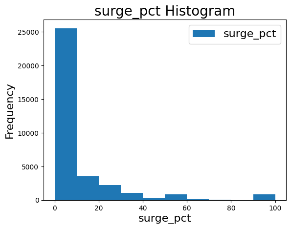

```python
fig, ax = plt.subplots()

make_hist(ax, 'surge_pct', df)
```

```
Min of weekday_pct: 0.0
Max of weekday_pct: 100.0
```

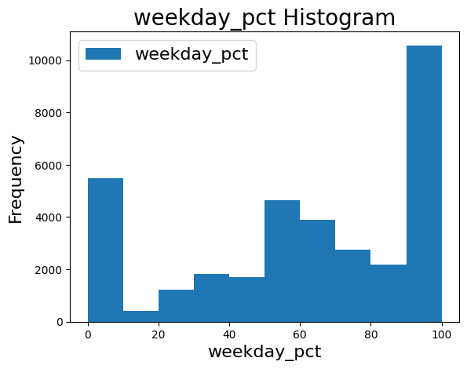

```python
fig, ax = plt.subplots()

make_hist(ax, 'weekday_pct', df)
```

```
Min of avg_dist: 0.0
Max of avg_dist: 79.69
```

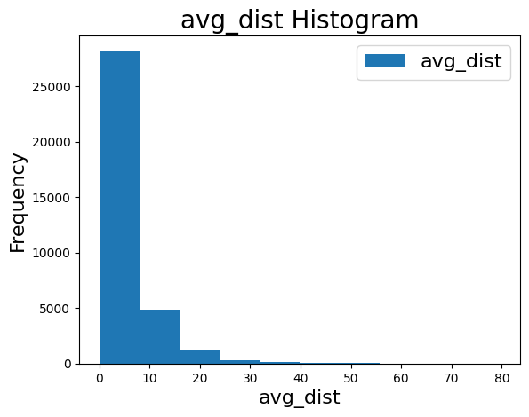

```python
fig, ax = plt.subplots()

make_hist(ax, 'avg_dist', df)
```

```
Min of avg_rating_by_driver: 1.0
Max of avg_rating_by_driver: 5.0
```

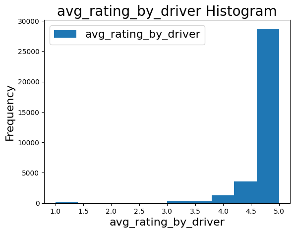

```python
fig, ax = plt.subplots()

make_hist(ax, 'avg_rating_by_driver', df)
```

```
[Text(1, 0, 'Retained'), Text(2, 0, 'Not retained')]
```

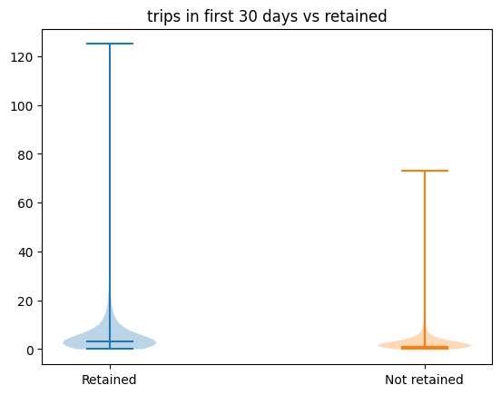

```python
fig, ax = plt.subplots()

ax.violinplot(df['trips_in_first_30_days'][df['retained'] == 1], showmedians=True, showextrema=True, positions=[1], widths=0.3,bw_method=0.5)
ax.violinplot(df['trips_in_first_30_days'][df['retained'] == 0], showmedians=True, showextrema=True, positions=[2], widths=0.3, bw_method=0.5)
ax.set_title('trips in first 30 days vs retained')
ax.set_xticks([1, 2])
ax.set_xticklabels(['Retained', 'Not retained'])
```

People will be retained if they take more trips in the first 30 days

```
[Text(1, 0, 'Retained'), Text(2, 0, 'Not retained')]
```

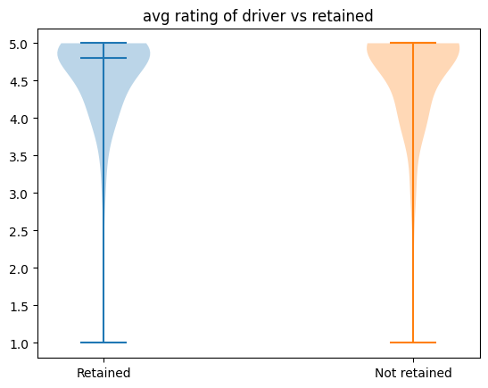

```python
fig, ax = plt.subplots()
mc = df.dropna()
ax.violinplot(mc['avg_rating_of_driver'][mc['retained'] == 1], showmedians=True, showextrema=True, positions=[1], widths=0.3,bw_method=0.5)
ax.violinplot(mc['avg_rating_of_driver'][mc['retained'] == 0], showmedians=True, showextrema=True, positions=[2], widths=0.3, bw_method=0.5)
ax.set_title('avg rating of driver vs retained')
ax.set_xticks([1, 2])
ax.set_xticklabels(['Retained', 'Not retained'])
```

```
[Text(1, 0, 'Retained'), Text(2, 0, 'Not retained')]
```

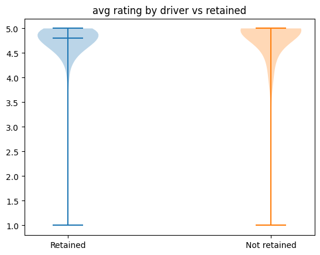

```python
fig, ax = plt.subplots()
mc = df.dropna()
ax.violinplot(mc['avg_rating_by_driver'][mc['retained'] == 1], showmedians=True, showextrema=True, positions=[1], widths=0.3,bw_method=0.5)
ax.violinplot(mc['avg_rating_by_driver'][mc['retained'] == 0], showmedians=True, showextrema=True, positions=[2], widths=0.3, bw_method=0.5)
ax.set_title('avg rating by driver vs retained')
ax.set_xticks([1, 2])
ax.set_xticklabels(['Retained', 'Not retained'])
```

```
[Text(1, 0, 'Retained'), Text(2, 0, 'Not retained')]
```

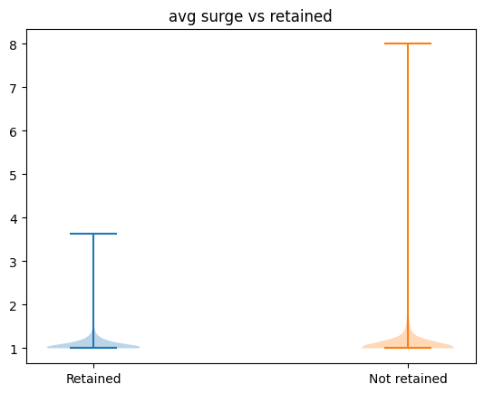

```python
fig, ax = plt.subplots()

ax.violinplot(df['avg_surge'][df['retained'] == 1], showmedians=True, showextrema=True, positions=[1], widths=0.3,bw_method=0.5)
ax.violinplot(df['avg_surge'][df['retained'] == 0], showmedians=True, showextrema=True, positions=[2], widths=0.3, bw_method=0.5)
ax.set_title('avg surge vs retained')
ax.set_xticks([1, 2])
ax.set_xticklabels(['Retained', 'Not retained'])
```

```
[Text(1, 0, 'Retained'), Text(2, 0, 'Not retained')]
```

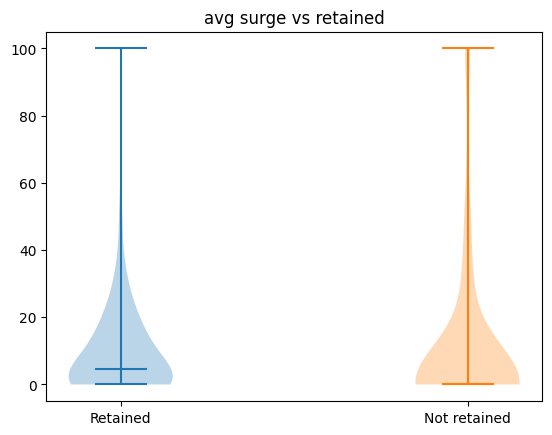

```python
fig, ax = plt.subplots()

ax.violinplot(df['surge_pct'][df['retained'] == 1], showmedians=True, showextrema=True, positions=[1], widths=0.3,bw_method=0.5)
ax.violinplot(df['surge_pct'][df['retained'] == 0], showmedians=True, showextrema=True, positions=[2], widths=0.3, bw_method=0.5)
ax.set_title('avg surge vs retained')
ax.set_xticks([1, 2])
ax.set_xticklabels(['Retained', 'Not retained'])
```

```
[Text(1, 0, 'Retained'), Text(2, 0, 'Not retained')]
```

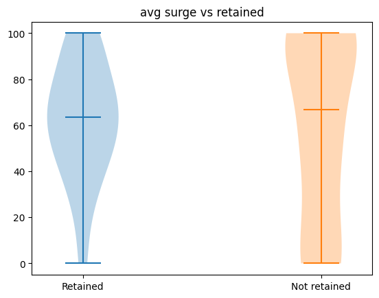

```python
fig, ax = plt.subplots()

ax.violinplot(df['weekday_pct'][df['retained'] == 1], showmedians=True, showextrema=True, positions=[1], widths=0.3,bw_method=0.5)
ax.violinplot(df['weekday_pct'][df['retained'] == 0], showmedians=True, showextrema=True, positions=[2], widths=0.3, bw_method=0.5)
ax.set_title('avg surge vs retained')
ax.set_xticks([1, 2])
ax.set_xticklabels(['Retained', 'Not retained'])
```

If people use it 65% of the time during the week it is the sweet spot of retaining people.

```
[Text(1, 0, 'Retained'), Text(2, 0, 'Not retained')]
```

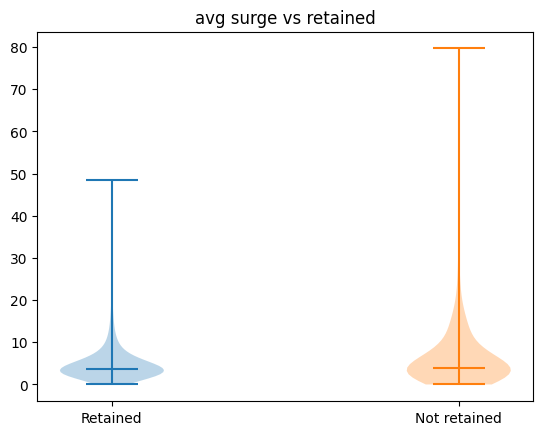

```python
fig, ax = plt.subplots()

ax.violinplot(df['avg_dist'][df['retained'] == 1], showmedians=True, showextrema=True, positions=[1], widths=0.3,bw_method=0.5)
ax.violinplot(df['avg_dist'][df['retained'] == 0], showmedians=True, showextrema=True, positions=[2], widths=0.3, bw_method=0.5)
ax.set_title('avg surge vs retained')
ax.set_xticks([1, 2])
ax.set_xticklabels(['Retained', 'Not retained'])
```

If they are going shorter routes they will stay with the service

```python
df.corr()
```

|  | trips_in_first_30_days | avg_rating_of_driver | avg_surge | surge_pct | premium_ride_service | weekday_pct | avg_dist | avg_rating_by_driver | retained |
| --- | --- | --- | --- | --- | --- | --- | --- | --- | --- |
| trips_in_first_30_days | 1.000000 | 0.002500 | -0.007819 | 0.001918 | 0.127093 | 0.073665 | -0.151874 | -0.041194 | 0.266742 |
| avg_rating_of_driver | 0.002500 | 1.000000 | -0.021730 | -0.000916 | -0.000706 | 0.016908 | 0.039670 | 0.124650 | -0.009915 |
| avg_surge | -0.007819 | -0.021730 | 1.000000 | 0.792721 | -0.076077 | -0.108904 | -0.076617 | 0.015496 | -0.011066 |
| surge_pct | 0.001918 | -0.000916 | 0.792721 | 1.000000 | -0.101761 | -0.146897 | -0.099145 | 0.023596 | 0.005503 |
| premium_ride_service | 0.127093 | -0.000706 | -0.076077 | -0.101761 | 1.000000 | 0.022969 | 0.019178 | 0.018232 | 0.233665 |
| weekday_pct | 0.073665 | 0.016908 | -0.108904 | -0.146897 | 0.022969 | 1.000000 | 0.095122 | 0.019452 | 0.027526 |
| avg_dist | -0.151874 | 0.039670 | -0.076617 | -0.099145 | 0.019178 | 0.095122 | 1.000000 | 0.090994 | -0.123884 |
| avg_rating_by_driver | -0.041194 | 0.124650 | 0.015496 | 0.023596 | 0.018232 | 0.019452 | 0.090994 | 1.000000 | -0.038337 |
| retained | 0.266742 | -0.009915 | -0.011066 | 0.005503 | 0.233665 | 0.027526 | -0.123884 | -0.038337 | 1.000000 |

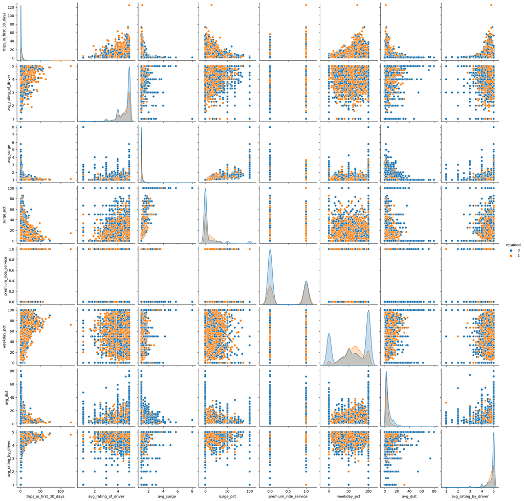

```python
sns.pairplot(df, hue='retained')
```

```
No artists with labels found to put in legend.  Note that artists whose label start with an underscore are ignored when legend() is called with no argument.
```

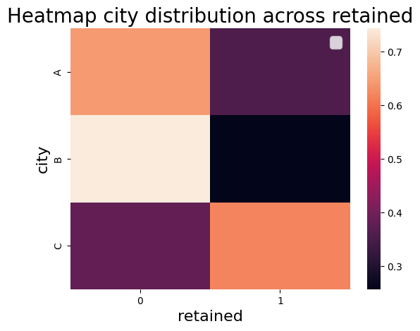

```python
fig, ax = plt.subplots()

sns.heatmap(pd.crosstab(df['city'], df['retained'], normalize='index'), xticklabels=True, yticklabels=True, ax=ax)
make_pretty(ax, 'Heatmap city distribution across retained', 'retained', 'city')
```

```
No artists with labels found to put in legend.  Note that artists whose label start with an underscore are ignored when legend() is called with no argument.
```

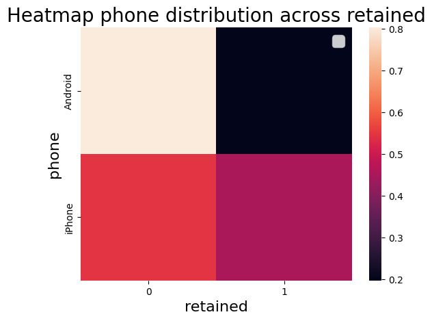

```python
fig, ax = plt.subplots()

sns.heatmap(pd.crosstab(df['phone'], df['retained'], normalize='index'), xticklabels=True, yticklabels=True, ax=ax)
make_pretty(ax, 'Heatmap phone distribution across retained', 'retained', 'phone')
```

I mean this is super weird. I did not expect there to be a difference between these two categories. For whatever reason, it seems that Android users are not retained. Maybe the UI on android is a lot worse than iphone.

```python
df.head()
```

|  | city | trips_in_first_30_days | signup_date | avg_rating_of_driver | avg_surge | last_trip_date | phone | surge_pct | premium_ride_service | weekday_pct | avg_dist | avg_rating_by_driver | retained |
| --- | --- | --- | --- | --- | --- | --- | --- | --- | --- | --- | --- | --- | --- |
| 0 | C | 4 | 2014-01-25 | 4.7 | 1.10 | 2014-06-17 | iPhone | 15.4 | True | 46.2 | 3.67 | 5.0 | 1 |
| 1 | B | 3 | 2014-01-06 | 4.3 | 1.00 | 2014-01-07 | iPhone | 0.0 | False | 100.0 | 0.77 | 5.0 | 0 |
| 2 | C | 9 | 2014-01-10 | 4.6 | 1.14 | 2014-06-29 | iPhone | 20.0 | True | 80.0 | 2.36 | 4.9 | 1 |
| 3 | A | 14 | 2014-01-27 | 4.4 | 1.19 | 2014-03-15 | Android | 11.8 | False | 82.4 | 3.13 | 4.9 | 0 |
| 4 | A | 2 | 2014-01-09 | 3.5 | 1.00 | 2014-06-06 | iPhone | 0.0 | True | 100.0 | 10.56 | 5.0 | 1 |

```
No artists with labels found to put in legend.  Note that artists whose label start with an underscore are ignored when legend() is called with no argument.
```

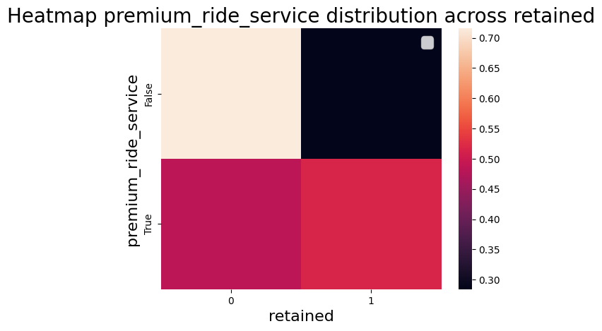

```python
fig, ax = plt.subplots()

sns.heatmap(pd.crosstab(df['premium_ride_service'], df['retained'], normalize='index'), xticklabels=True, yticklabels=True, ax=ax)
make_pretty(ax, 'Heatmap premium_ride_service distribution across retained', 'retained', 'premium_ride_service')
```

### Train / Test Split

```python
from sklearn.model_selection import train_test_split


X_train, X_test, y_train, y_test = train_test_split(df[df.columns[0:-1]], df[df.columns[-1]], test_size=0.3, random_state=42)
```

### Pipe work

```python
from sklearn.pipeline import Pipeline
from sklearn.impute import SimpleImputer
from sklearn.preprocessing import StandardScaler
from sklearn.compose import ColumnTransformer
from sklearn.preprocessing import OneHotEncoder
from sklearn.preprocessing import FunctionTransformer
from sklearn.linear_model import LogisticRegression

num_attribs = ['trips_in_first_30_days', 'avg_rating_of_driver', 'avg_surge', 'surge_pct', 'weekday_pct', 'avg_dist', 'avg_rating_by_driver']
cat_attribs = ['city', 'premium_ride_service', 'phone']

def extract_date_time_signup(X):
    X = X.copy()

    X['signup_date_month'] = X['signup_date'].dt.month
    X['signup_date_day'] = X['signup_date'].dt.day
    return X[['signup_date_month', 'signup_date_day']]







num_pipeline = Pipeline([
    ('imputer', SimpleImputer(strategy='median')),
    ('std_scaler', StandardScaler())
])

full_pipe = Pipeline([
    ('preprocessor', ColumnTransformer([
        ('num', num_pipeline, num_attribs),
        ('date', FunctionTransformer(extract_date_time_signup), ['signup_date']),
        ('cat', OneHotEncoder(), cat_attribs)
    ]))
])


features = full_pipe.fit_transform(X_train)
```

### Trying some modeling

```python
from sklearn.model_selection import cross_validate
from sklearn.dummy import DummyClassifier

dummy = DummyClassifier(strategy='most_frequent')
cross_validate(dummy, features, y_train, cv=5)
```

```
{'fit_time': array([0.00323606, 0.        , 0.        , 0.00858665, 0.00348783]),
 'score_time': array([0.00049806, 0.        , 0.        , 0.        , 0.        ]),
 'test_score': array([0.6250515 , 0.62497424, 0.62497424, 0.62497424, 0.62497424])}
```

```python
from sklearn.linear_model import LogisticRegression

clf = LogisticRegression()
cross_validate(clf, features, y_train, cv=5)
```

```
{'fit_time': array([0.15861821, 0.14152384, 0.1654923 , 0.12406993, 0.09172893]),
 'score_time': array([0.00863361, 0.00799775, 0.00179029, 0.        , 0.        ]),
 'test_score': array([0.73382777, 0.73397898, 0.73851226, 0.72676695, 0.72635483])}
```

```python
from sklearn.ensemble import RandomForestClassifier

clf = RandomForestClassifier()

cross_validate(clf, features, y_train, cv=5)
```

```
{'fit_time': array([1.93100929, 1.88562489, 1.89453006, 1.89168763, 1.86715484]),
 'score_time': array([0.08319187, 0.0807898 , 0.10522676, 0.07964635, 0.0850482 ]),
 'test_score': array([0.80696333, 0.79909334, 0.80919019, 0.79414795, 0.79641459])}
```

```python
from sklearn.ensemble import AdaBoostClassifier

clf = AdaBoostClassifier()
cross_validate(clf, features, y_train, cv=5)
```

```
{'fit_time': array([0.54875278, 0.55861974, 0.54284406, 0.57741046, 0.53701115]),
 'score_time': array([0.02491951, 0.03216767, 0.02407265, 0.02235842, 0.02284217]),
 'test_score': array([0.80840544, 0.8081599 , 0.81372347, 0.80012363, 0.79991758])}
```

```python
from sklearn.neighbors import KNeighborsClassifier


clf = KNeighborsClassifier()
cross_validate(clf, features, y_train, cv=5)
```

```
{'fit_time': array([0.00340271, 0.00337338, 0.00784159, 0.00755525, 0.00556421]),
 'score_time': array([0.18984461, 0.19087267, 0.18180394, 0.18635035, 0.18463373]),
 'test_score': array([0.75463535, 0.75582114, 0.76056048, 0.74593035, 0.74593035])}
```

```python
from sklearn.neural_network import MLPClassifier

clf = MLPClassifier(hidden_layer_sizes=20, activation='relu', solver='lbfgs', alpha=0.01, learning_rate='adaptive', max_iter=500, random_state=42, early_stopping=True)

cross_validate(clf, features, y_train, cv=5)
```

```
{'fit_time': array([6.16993093, 6.04149389, 5.80888653, 5.97501802, 5.97459674]),
 'score_time': array([0.        , 0.        , 0.00802469, 0.00822282, 0.        ]),
 'test_score': array([0.80346106, 0.79991758, 0.81042654, 0.79744488, 0.7865238 ])}
```

### Hyperparam tuning

```python
from sklearn.model_selection import GridSearchCV

param_grid = {
    'max_depth' : [1, 2, 3, 4, 5, 6],
    'n_estimators' : [10, 50, 75, 100, 150, 250]

}

gc = GridSearchCV(RandomForestClassifier(), param_grid=param_grid)
gc.fit(features, y_train)
```

```
GridSearchCV(estimator=RandomForestClassifier(),
             param_grid={'max_depth': [1, 2, 3, 4, 5, 6],
                         'n_estimators': [10, 50, 75, 100, 150, 250]})
```

```python
rf = gc.best_estimator_
```

```python
X_test_prepped = full_pipe.fit_transform(X_test)
pred = rf.predict(X_test_prepped)
```

```python
from sklearn.metrics import accuracy_score

accuracy_score(y_test, pred)
```

```
0.7985576923076924
```

```
<sklearn.metrics._plot.confusion_matrix.ConfusionMatrixDisplay at 0x1ca7ae22ec0>
```

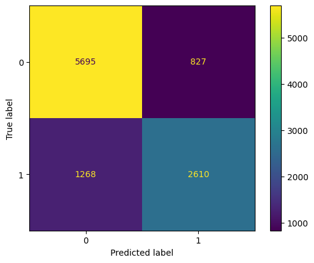

```python
from sklearn.metrics import confusion_matrix, ConfusionMatrixDisplay



x = confusion_matrix(y_test, pred)
tn, fp, fn, tp = x.ravel()
ConfusionMatrixDisplay(confusion_matrix=x, display_labels=rf.classes_).plot()
```